# STAC32 Final Project: Racial Disparity in Wealth Distribution in the USA

Agam Chavan, Felix Cheung, Stephanie Wong, Akaash Palaparthy, Kritika Pandey

**Abstract**  
This project aims to throw light on the disparity experienced by racial and minority groups in the USA with respect to wealth distribution and student loans. While everyone is aware of the racial inequalities present in the USA, this project quantifies the same with data sourced from [Urban Institute](https://apps.urban.org/features/wealth-inequality-charts) and the [US Census](https://www.census.gov/data/tables/time-series/demo/income-poverty/historical-income-households.html), via [tidytuesday](https://github.com/rfordatascience/tidytuesday/blob/master/data/2021/2021-02-09/readme.md). The datasets used in our analysis include information on race, income level and student debt. Through statistical analysis, we realised that the average family wealth (normalized to 2016) for White families is significantly higher than that for Black or Hispanic families in the US. This disparity has existed since several years. There is a high correlation between race and average income (P < 0.05) and the largest wealth disparity exists between White and Black races in the US. To provide historical context, we also consider the Civil Rights Movement and any impact it might have had on social indicators. Disproportionate wealth distribution influences one’s need for student loans. Students from the Black community had a higher percentage of debt, compared to their White and Hispanic colleagues.  
**Introduction**  
This project focuses on the wealth gap created as a result of systemic/institutional racism. We look at historical data and the impact of the Civil Rights Movement on curbing the gap. Racial inequality is defined as “imbalances in the distribution of power, economic resources and opportunities” ([Shapiro, 2004](https://archive.org/details/hiddencostofbein00shap_0)). Such social injustices have been present in American society since several years, with several monumental efforts taken to right this wrong, most notably the Civil Rights Movement (1954-1968). This ended legalized racial discrimination, disenfranchisement and racial segregation in the US. Unfortunately, these reforms have not been able to completely curb institutional racism in the US. It is a form of racism “that is embedded in the laws and regulations of a society”, and “manifests as discrimination in areas such as criminal justice, employment, housing, healthcare, education and political representation” ([Shapiro, 2004](https://archive.org/details/hiddencostofbein00shap_0)). This project focuses on the disproportionate disadvantages faced by minority communities in the US, especially in income levels, family wealth and the burden of student loans. We have decided to focus on income, wealth and student debt since access to money and education largely determine an individual’s quality of life and standing in society. Most of our findings are in line with what one might expect, given the social atmosphere in the US. However, being able to support known facts with quantified evidence and data is always a benefit and provides new perspectives.  
**Methodology**

```r
library(tidytuesdayR)
library(tidyverse)
library(smmr)
library(PMCMRplus)
```

```r
A1<-read_csv('https://raw.githubusercontent.com/rfordatascience/tidytuesday/master/data/2021/2021-02-09/income_distribution.csv')
A1
```

| year | race | number | income_median | income_med_moe | income_mean | income_mean_moe | income_bracket | income_distribution |
| --- | --- | --- | --- | --- | --- | --- | --- | --- |
| 2019 | All Races | 128451000 | 68703 | 904 | 98088 | 1042 | Under $15,000 | 9.1 |
| 2019 | All Races | 128451000 | 68703 | 904 | 98088 | 1042 | $15,000 to $24,999 | 8.0 |
| 2019 | All Races | 128451000 | 68703 | 904 | 98088 | 1042 | $25,000 to $34,999 | 8.3 |
| 2019 | All Races | 128451000 | 68703 | 904 | 98088 | 1042 | $35,000 to $49,999 | 11.7 |
| 2019 | All Races | 128451000 | 68703 | 904 | 98088 | 1042 | $50,000 to $74,999 | 16.5 |
| 2019 | All Races | 128451000 | 68703 | 904 | 98088 | 1042 | $75,000 to $99,999 | 12.3 |
| 2019 | All Races | 128451000 | 68703 | 904 | 98088 | 1042 | $100,000 to $149,999 | 15.5 |
| 2019 | All Races | 128451000 | 68703 | 904 | 98088 | 1042 | $150,000 to $199,999 | 8.3 |
| 2019 | All Races | 128451000 | 68703 | 904 | 98088 | 1042 | $200,000 and over | 10.3 |
| 2018 | All Races | 128579000 | 64324 | 704 | 91652 | 914 | Under $15,000 | 10.1 |

[output cut: 990 more lines]

```r
A1 %>% count(race)
```

| race | n |
| --- | --- |
| All Races | 477 |
| Asian Alone | 297 |
| Asian Alone or in Combination | 162 |
| Black Alone | 477 |
| Black Alone or in Combination | 162 |
| Hispanic (Any Race) | 432 |
| White Alone | 477 |
| White Alone, Not Hispanic | 432 |

1. use the data to find income disparity throughout years (impact of civil rights movement) and then do racial ambiguity comparisons.
1. Specific race-only income levels- using mean/median.
2. Racially mixed income separately evaluated.
2. Average income shows the income, the races would have earned if the total income was equally distributed among all races.
3. Median is the income that people earn in the household more or less, it’s like middle-class income for a race.- I have used mean to see the income differences between races and median to see the impact of civil rights(because its not giving me the average but the middle income of sorts)

# Impact of Civil rights movement: (extent to which its different)

### after civil rights movement:

#### Before doing the analysis, we would be tidying the data first:

```r
A1 %>%
  select(year:race, income_median:income_mean, income_bracket:income_distribution) %>%
  slice( 955:1386, 1549:2025, 2188:2916) %>% filter(year>=1980)-> households
households
```

| year | race | income_median | income_med_moe | income_mean | income_bracket | income_distribution |
| --- | --- | --- | --- | --- | --- | --- |
| 2019 | White Alone, Not Hispanic | 76057 | 876 | 106659 | Under $15,000 | 7.3 |
| 2019 | White Alone, Not Hispanic | 76057 | 876 | 106659 | $15,000 to $24,999 | 7.3 |
| 2019 | White Alone, Not Hispanic | 76057 | 876 | 106659 | $25,000 to $34,999 | 7.5 |
| 2019 | White Alone, Not Hispanic | 76057 | 876 | 106659 | $35,000 to $49,999 | 11.0 |
| 2019 | White Alone, Not Hispanic | 76057 | 876 | 106659 | $50,000 to $74,999 | 16.2 |
| 2019 | White Alone, Not Hispanic | 76057 | 876 | 106659 | $75,000 to $99,999 | 12.8 |
| 2019 | White Alone, Not Hispanic | 76057 | 876 | 106659 | $100,000 to $149,999 | 16.8 |
| 2019 | White Alone, Not Hispanic | 76057 | 876 | 106659 | $150,000 to $199,999 | 9.3 |
| 2019 | White Alone, Not Hispanic | 76057 | 876 | 106659 | $200,000 and over | 11.8 |
| 2018 | White Alone, Not Hispanic | 71922 | 664 | 100041 | Under $15,000 | 8.0 |

[output cut: 990 more lines]

#### Checking with normality and equal spread:

We would be using boxplots and normal quantile plots to determine which test we would do.

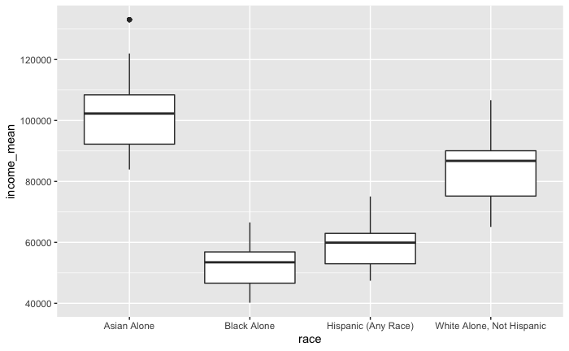

```r
ggplot(households, aes(x = race, y = income_mean)) + geom_boxplot()
```

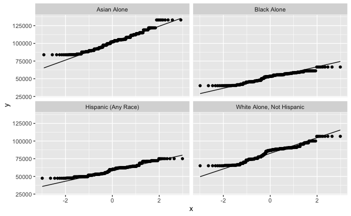

```r
ggplot(households, aes(sample = income_mean)) + stat_qq() +
  stat_qq_line() + facet_wrap( ~ race)
```

```r
households %>% count(race)
```

| race | n |
| --- | --- |
| Asian Alone | 297 |
| Black Alone | 360 |
| Hispanic (Any Race) | 360 |
| White Alone, Not Hispanic | 360 |

Observation 1: For the four major groups of race, they seem to skewed to the left in the boxplots. In the normal quantile plot, most of the points appear to be close to the line. There are also a few outliers on the top right of the plot of Asians group. But keep in mind that for the Asians group, their observations are limited as well, they are the smallest group of people being analysed. Based on the above table, the number of observations being high (above 100 each) gives us the benefit of the doubt, so we would be assuming normality from now by applying the central limit theorem.

Observation 2: The Asians generally make the most money because their progression is much steeper than any other race. White has the second best progression (we will prove it next, these are just hypothesis based on the graph). Hispanics have a better income curve than black people. Overall, the Asian and White group appears to have more spread than others.

Based on the boxplots and normal quantile plots, we observed normal distribution and unequal spreads. Therefore, we would be doing the Welch ANOVA test in the next part.

#### The relationship between race and income_mean:

We would be running an analysis of variance (Welch ANOVA) below. $Ho$: All race groups have same income mean. $Ha$: Not all income means the same, at least one race group is different from others.

```r
oneway.test(income_mean~race,data=households)
```

```
    One-way analysis of means (not assuming equal variances)

data:  income_mean and race
F = 1912.4, num df = 3.00, denom df = 715.24, p-value < 2.2e-16
```

Observation 1: There is a high correlation between income mean and the races, p-value is very small. As the p-value < 0.05, there is signifance difference within the race groups. Therefore, we can reject the null that income means are equal. As there is more than 3 groups, we would do a Games-Howell test to see where these differences lie.

```r
gamesHowellTest(income_mean~factor(race),data=households)
```

```
    Pairwise comparisons using Games-Howell test

data: income_mean by factor(race)
```

```
                          Asian Alone Black Alone Hispanic (Any Race)
Black Alone               < 2e-16     -           -
Hispanic (Any Race)       < 2e-16     < 2e-16     -
White Alone, Not Hispanic 5.0e-10     2.7e-10     < 2e-16
```

```
P value adjustment method: none
alternative hypothesis: two.sided
```

## before civil right movement

## tidying up data

```r
A1 %>%
  select(year:race, income_median:income_mean, income_bracket:income_distribution) %>%
  slice(955:1385, 1549:2025, 2188:2916) %>% filter(year<=1980)-> household1
household1
```

| year | race | income_median | income_med_moe | income_mean | income_bracket | income_distribution |
| --- | --- | --- | --- | --- | --- | --- |
| 1980 | White Alone, Not Hispanic | 56327 | 526 | 65765 | Under $15,000 | 10.3 |
| 1980 | White Alone, Not Hispanic | 56327 | 526 | 65765 | $15,000 to $24,999 | 9.9 |
| 1980 | White Alone, Not Hispanic | 56327 | 526 | 65765 | $25,000 to $34,999 | 9.8 |
| 1980 | White Alone, Not Hispanic | 56327 | 526 | 65765 | $35,000 to $49,999 | 14.5 |
| 1980 | White Alone, Not Hispanic | 56327 | 526 | 65765 | $50,000 to $74,999 | 21.9 |
| 1980 | White Alone, Not Hispanic | 56327 | 526 | 65765 | $75,000 to $99,999 | 14.9 |
| 1980 | White Alone, Not Hispanic | 56327 | 526 | 65765 | $100,000 to $149,999 | 13.0 |
| 1980 | White Alone, Not Hispanic | 56327 | 526 | 65765 | $150,000 to $199,999 | 3.6 |
| 1980 | White Alone, Not Hispanic | 56327 | 526 | 65765 | $200,000 and over | 2.0 |
| 1979 | White Alone, Not Hispanic | 57651 | 526 | 67724 | Under $15,000 | 10.2 |

[output cut: 277 more lines]

#### Checking with normality and equal spread:

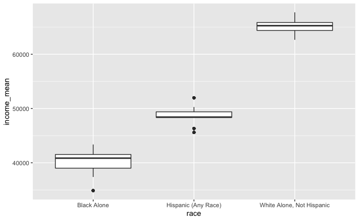

```r
ggplot(household1, aes(x = race, y = income_mean)) + geom_boxplot()
```

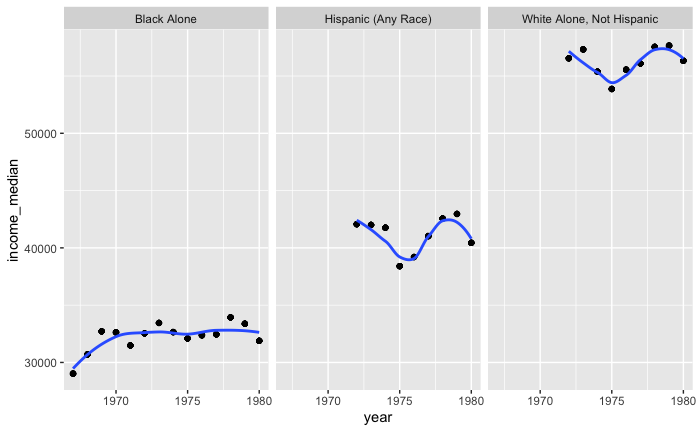

```r
ggplot(household1, aes(y = income_median, x = year)) +
  geom_point() + geom_smooth(se = F) + facet_wrap(~race)
```

Observation 1: No Asian data collected before 1980. Observation 2: There are outliers for the Black and Hispanic group. We observed there is right-skewed distribution in Hispanic group and left-skewed distribution in Black group. As there is no normality so we would use median test from this point forward.

#### The relationship between race and income_median:

$Ho$: Medians for all race groups are equal $Ha$: Not all income medians the same, at least one race group is different from others.

```r
median_test(household1,income_median,race)
```

```
$table
                           above
group                       above below
  Black Alone                   0   126
  Hispanic (Any Race)          63     9
  White Alone, Not Hispanic    80     0

$test
```

| what | value |
| --- | --- |
| statistic | 2.464739e+02 |
| df | 2.000000e+00 |
| P-value | 3.012134e-54 |

```
NA
```

Observation 2: The p-value is very small so there is a correlation between race and income. As p-value < 0.05, which means that at least one group has a different median than other race groups. If we go back to the boxplots, we can see the Black group has the lowest median. If you remember, the middle line in each of the boxplots represent the median. But the point is to verify this using a statistical test. In order to do this, we are going to do the pairwise_median_test.

```r
pairwise_median_test(household1,income_median,race)
```

| g1 | g2 | p_value | adj_p_value |
| --- | --- | --- | --- |
| Black Alone | Hispanic (Any Race) | 1.160032e-31 | 3.480095e-31 |
| Black Alone | White Alone, Not Hispanic | 1.921002e-31 | 5.763007e-31 |
| Hispanic (Any Race) | White Alone, Not Hispanic | 6.336158e-35 | 1.900847e-34 |

### Income disparity before and after civil rights movement:

This time we would also include the group of Asians in the data.

#### Comparison through median:

```r
household1 %>% summarize(med = median(income_median)) %>% pull(med) -> m1
m1
```

```
[1] 39203
```

```r
households %>% summarize(med = median(income_median)) %>% pull(med) -> m
m
```

```
[1] 50791
```

Observation: After the civil rights movement, the overall median of income median has increased. The factor of change may be mainly caused by adding the Asian group into the data.

#### Comparison through median test:

$Ho$: Medians for all race groups are equal $Ha$: Not all income medians the same, at least one race group is different from others.

```r
median_test(households,income_median,race)
```

```
$table
                           above
group                       above below
  Asian Alone                 297     0
  Black Alone                   0   360
  Hispanic (Any Race)          27   324
  White Alone, Not Hispanic   360     0

$test
```

| what | value |
| --- | --- |
| statistic | 1.268308e+03 |
| df | 3.000000e+00 |
| P-value | 1.107588e-274 |

```
NA
```

Observation 1: Once again, we can clearly see the income disparity through the above table. But this time, not only the White group’s income median are all above the overall median, there is also the Asian group; oppositely, there is still not a single data point of the Black group making above the median of all income_median level. The income disparity has worsened for Hispanics, compared to our data before civil rights movement.

Observation 2: The p-value is even smaller than before so there is still a correlation between race and income. As p-value < 0.05, which means that at least one group has a different median than other race groups. Mood’s median test is really similar to the F-test in ANOVA: it’s testing the null hypothesis that the race groups all have the same median (of income_median), against the alternative that the null is not true. We rejected this null, but we don’t know which race group differ significantly from which. To resolve this, we do all the pairwise Mood’s median tests on all pairs of groups, and we would look at the adjusted P-values to see how the race group differ in terms of income median.

```r
pairwise_median_test(households,income_median,race)
```

| g1 | g2 | p_value | adj_p_value |
| --- | --- | --- | --- |
| Asian Alone | Black Alone | 2.938575e-121 | 1.763145e-120 |
| Asian Alone | Hispanic (Any Race) | 2.938575e-121 | 1.763145e-120 |
| Asian Alone | White Alone, Not Hispanic | 2.228097e-65 | 1.336858e-64 |
| Black Alone | Hispanic (Any Race) | 4.846412e-41 | 2.907847e-40 |
| Black Alone | White Alone, Not Hispanic | 1.338626e-158 | 8.031755e-158 |
| Hispanic (Any Race) | White Alone, Not Hispanic | 2.469490e-143 | 1.481694e-142 |

Observation: By comparing income_median of each race group to another, they all have significant differences because their adjusted P-value < 0.05

# Racial ambiguity:

### Before doing the analysis, we would be tidying the data first:

```r
A1 %>%
  select(year:race, income_median:income_mean, income_bracket:income_distribution) %>%
  slice(-1:-477,-955:-1386,-1549:-2025, -2188:-2916) -> Racial_a
Racial_a
```

| year | race | income_median | income_med_moe | income_mean | income_bracket | income_distribution |
| --- | --- | --- | --- | --- | --- | --- |
| 2019 | White Alone | 72204 | 800 | 101732 | Under $15,000 | 7.8 |
| 2019 | White Alone | 72204 | 800 | 101732 | $15,000 to $24,999 | 7.5 |
| 2019 | White Alone | 72204 | 800 | 101732 | $25,000 to $34,999 | 8.0 |
| 2019 | White Alone | 72204 | 800 | 101732 | $35,000 to $49,999 | 11.5 |
| 2019 | White Alone | 72204 | 800 | 101732 | $50,000 to $74,999 | 16.7 |
| 2019 | White Alone | 72204 | 800 | 101732 | $75,000 to $99,999 | 12.7 |
| 2019 | White Alone | 72204 | 800 | 101732 | $100,000 to $149,999 | 16.3 |
| 2019 | White Alone | 72204 | 800 | 101732 | $150,000 to $199,999 | 8.7 |
| 2019 | White Alone | 72204 | 800 | 101732 | $200,000 and over | 10.8 |
| 2018 | White Alone | 68156 | 657 | 95650 | Under $15,000 | 8.5 |

[output cut: 791 more lines]

Note: White only has Hispanics mixed**

### Checking with normality and equal spread:

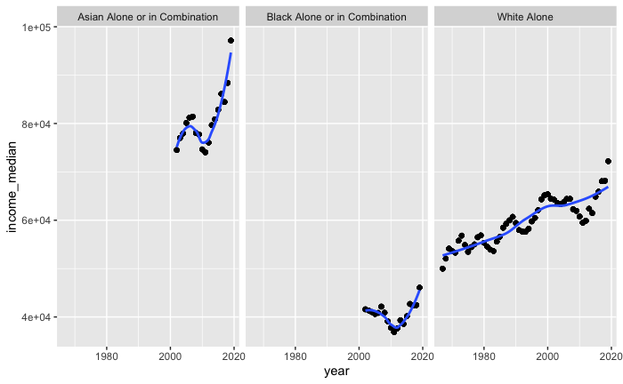

```r
ggplot(Racial_a, aes(y = income_median, x = year)) +
  geom_point() + geom_smooth(se = F) + facet_wrap(~race)
```

Observation: We can observe the distribution is not normal and it does not have equal SDs. Therefore, we would use Mood’s Median Test in the following part.

### Relationship between three major races and income_median:

```r
median_test(Racial_a,income_median,race)
```

```
$table
                               above
group                           above below
  Asian Alone or in Combination   162     0
  Black Alone or in Combination     0   162
  White Alone                     234   234

$test
```

| what | value |
| --- | --- |
| statistic | 3.240000e+02 |
| df | 2.000000e+00 |
| P-value | 4.408531e-71 |

```
NA
```

Observation 1: Clear disparity even among mixed races, the biggest racial difference is among people from black-African origin. It is interesting to see that racially ambiguous white people make less money compared to visible white (just a hint of existence of institutional racism).

Observation 2: P < 0.05, which indicates that at least one race group has a different median than other groups.

# Further discussion in unequal income distribution:

```r
A1 %>%
  select(year:race, income_bracket:income_distribution) %>%
  slice(-1:-477) -> income_disparity
income_disparity
```

| year | race | income_bracket | income_distribution |
| --- | --- | --- | --- |
| 2019 | White Alone | Under $15,000 | 7.8 |
| 2019 | White Alone | $15,000 to $24,999 | 7.5 |
| 2019 | White Alone | $25,000 to $34,999 | 8.0 |
| 2019 | White Alone | $35,000 to $49,999 | 11.5 |
| 2019 | White Alone | $50,000 to $74,999 | 16.7 |
| 2019 | White Alone | $75,000 to $99,999 | 12.7 |
| 2019 | White Alone | $100,000 to $149,999 | 16.3 |
| 2019 | White Alone | $150,000 to $199,999 | 8.7 |
| 2019 | White Alone | $200,000 and over | 10.8 |
| 2018 | White Alone | Under $15,000 | 8.5 |

[output cut: 990 more lines]

This is from the github website: they already summarize for us. We can use this data to strengthen our point on income disparity, we just focused to compare the 3 biggest players of races in following analysis: Asian, White and Black.

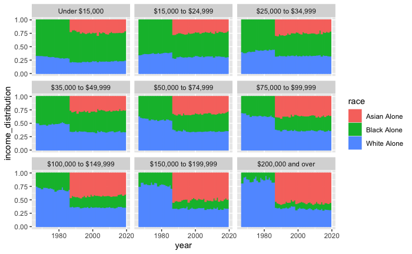

```r
income_levels <- c(
  "Under $15,000",
  "$15,000 to $24,999",
  "$25,000 to $34,999",
  "$35,000 to $49,999",
  "$50,000 to $74,999",
  "$75,000 to $99,999",
  "$100,000 to $149,999",
  "$150,000 to $199,999",
  "$200,000 and over")

income_disparity %>%
  filter(race %in% c("Black Alone", "White Alone", "Asian Alone")) %>%
  mutate(income_bracket = factor(income_bracket, levels = income_levels)) %>%
  ggplot(aes(x = year, y = income_distribution, color = race, fill = race)) +
  geom_col(position = "fill") +
  facet_wrap(~income_bracket)
```

Observation 1: The Asian group generally makes the most money in the recent years, while majority of Black people make less than 75000 a year, white people are mostly equally distributed in all income ranges.

## In the next section of our analysis, we will be looking at how different races in the US are exposed differently to student loans.

```r
student_debt <- readr::read_csv('https://raw.githubusercontent.com/rfordatascience/tidytuesday/master/data/2021/2021-02-09/student_debt.csv')
student_debt %>% arrange(year) %>% arrange(race)
```

| year | race | loan_debt | loan_debt_pct |
| --- | --- | --- | --- |
| 1989 | Black | 1160.5680 | 0.1788198 |
| 1992 | Black | 927.4824 | 0.1382771 |
| 1995 | Black | 1922.8860 | 0.1696231 |
| 1998 | Black | 1325.2170 | 0.1406358 |
| 2001 | Black | 2223.7190 | 0.1849185 |
| 2004 | Black | 3987.1770 | 0.2160084 |
| 2007 | Black | 6111.0280 | 0.2834677 |
| 2010 | Black | 9510.1000 | 0.3212868 |
| 2013 | Black | 10302.6600 | 0.4122773 |
| 2016 | Black | 14224.7700 | 0.4183588 |

[output cut: 20 more lines]

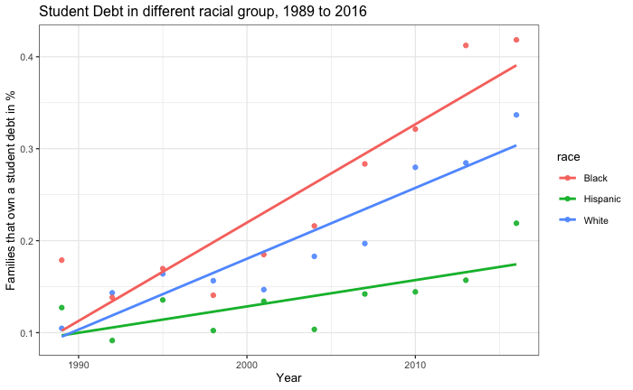

```r
ggplot(student_debt, aes(x = year, y = loan_debt_pct, colour = race)) +
  geom_point(size = 1.5, alpha = 0.9) +
  geom_smooth(method = "lm", se = FALSE) +
  labs(x = "Year", y = "Families that own a student debt in %") +
  ggtitle("Student Debt in different racial group, 1989 to 2016") +
  theme_bw(base_size = 10)
```

```r
NA
```

Student Debt in different racial groups, from 1989 ~ 2016

Observation: The graph clearly shows that the percentage of families with a student loan, across races, has increased over time. The trends for Hispanic and White student debt demonstrate multicollinearity and overall, the lack of sufficient data points means that these results may not be 100% accurate. There is a higher percentage of Black families with a student loan, perhaps since average family wealth levels for Black families is considerably lower than White families, hence increasing their dependence on loans to pursue post-secondary education.

```r
race_wealth <- readr::read_csv('https://raw.githubusercontent.com/rfordatascience/tidytuesday/master/data/2021/2021-02-09/race_wealth.csv')
race_wealth %>%
  arrange(type) %>%
  arrange(year) %>%
  arrange(wealth_family)
```

| type | year | race | wealth_family |
| --- | --- | --- | --- |
| Median | 1963 | Non-White | 2467.403 |
| Median | 1989 | Black | 8023.198 |
| Median | 1989 | Hispanic | 9329.301 |
| Median | 1983 | Hispanic | 9644.209 |
| Median | 1992 | Hispanic | 11387.300 |
| Median | 1983 | Black | 13324.170 |
| Median | 1983 | Non-White | 13324.171 |
| Median | 2013 | Black | 13486.850 |
| Median | 2013 | Hispanic | 14229.240 |
| Median | 1998 | Hispanic | 14503.750 |

[output cut: 86 more lines]

Note: Some data points were not included properly and hence filled with ‘NA’. For the purpose of this analysis, we will ignore such data points.

This part analyses wealth disparity over the years

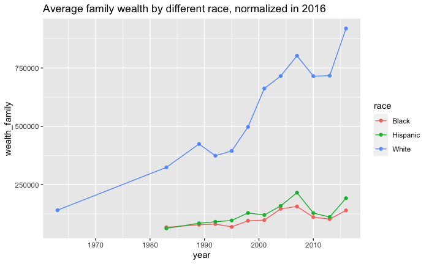

```r
race_wealth %>%
  filter(!is.na(wealth_family), race != "Non-White", type == "Average") %>%
  ggplot(aes( x = year, y = wealth_family)) +
  geom_line(aes(colour = race)) +
  geom_point(aes(colour = race)) +
  ggtitle("Average family wealth by different race, normalized in 2016")
```